# TEMA 2 : Agrupamiento de OTUs

## 2.6 Desrreplicación

Consiste en detectar las secuencias nucleotídicas que son idénticas, tomar una secuencia representativa de cada grupo de secuencias y generar una tabla de frecuencias con esos datos.

Usa el siguiente código para hacer la desrreplicación:

```bash
qiime vsearch dereplicate-sequences \
 --i-sequences filtered_seqs/filtered_sequences.qza \
 --output-dir dereplicated_seqs
```

Alternativamente, pueden usar el `FeatureTable[Frequency]` y `FeatureData[Sequence]` que obtienen a partir de un flujo de trabajo de denoising como el de dada2 o deblur.

Hagamos el ejercicio de hacer denoising con dada2, para después agrupar OTUs más adelante.

```bash
qiime dada2 denoise-paired \
  --i-demultiplexed-seqs demux.qza \
  --p-trim-left-f 13 \
  --p-trim-left-r 13 \
  --p-trunc-len-f 150 \
  --p-trunc-len-r 150 \
  --output-dir dada \
    --p-n-threads 6
```

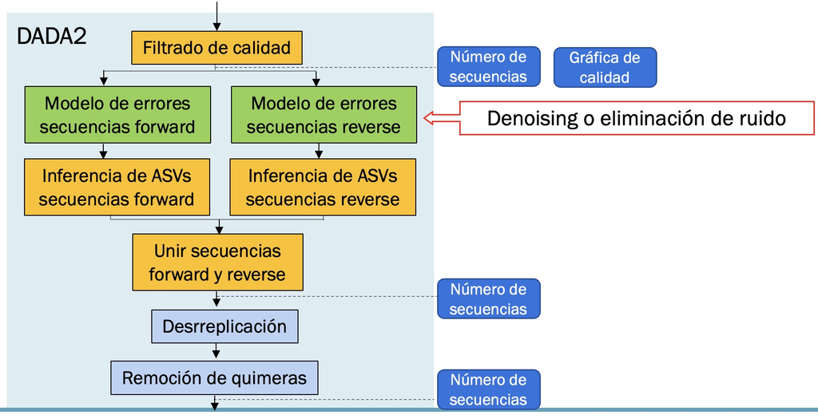

## 2.7 Clustering o agrupación de OTUs

### 2.7.1 *De novo*

El proceso de clustering *de novo* implica agrupar secuencias similares sin usar una base de datos de referencia predefinida.

Se lleva a cabo mediante algoritmos que comparan las secuencias entre sí y agrupan aquellas que comparten similitudes por arriba de un umbral definido. Este enfoque es útil cuando no se dispone de una base de datos exhaustiva para la identificación taxonómica precisa o cuando se exploran comunidades microbianas poco estudiadas.

El clustering *de novo* permite obtener una visión general de las diferentes unidades taxonómicas presentes en una muestra, aunque tiene la desventaja que puede sobreestimar la diversidad si las secuencias son de mala calidad.

Usa el siguiente código para agrupar secuencias *de novo*.

```bash
qiime vsearch cluster-features-de-novo \
 --i-sequences dereplicated_seqs/dereplicated_sequences.qza \
 --i-table dereplicated_seqs/dereplicated_table.qza \
 --p-perc-identity 0.97 \
 --p-threads 4 \
 --output-dir cluster_denovo
```

### 2.7.2 Closed-reference

El método closed-reference de agrupación de OTUs implica comparar las secuencias de ADN con una base de datos de referencia conocida. Solo las secuencias que tienen una alta similitud con las secuencias de la base de datos de referencia se agrupan como OTUs. Las secuencias que no coinciden con la base de datos de referencia no se incluyen en el análisis.

Este enfoque tiene la ventaja de asignar las secuencias a taxonomías conocidas, lo que puede proporcionar información precisa sobre la identidad taxonómica de los microorganismos presentes en la muestra. Sin embargo, puede excluir información sobre microorganismos no representados en la base de datos de referencia, lo que limita la capacidad de descubrir nuevas especies o variantes genéticas únicas.

Usa el siguiente código para agrupar secuencias *closed-reference*.

```bash
 qiime vsearch cluster-features-closed-reference \
  --i-reference-sequences ../tema1/pyro/silva-138-99-seqs.qza \
  --i-sequences dereplicated_seqs/dereplicated_sequences.qza \
  --i-table dereplicated_seqs/dereplicated_table.qza \
  --p-perc-identity 0.97 \
  --output-dir cluster_closed \
  --p-threads 4
```

Nota que estamos incluyendo este parámetro: `--i-reference-sequences`

### 2.7.3 Open-reference

En el método open-reference, las secuencias se comparan primero con una base de datos de referencia conocida, similar al enfoque closed-reference. **Sin embargo, las secuencias que no encuentran una coincidencia cercana con la base de datos de referencia se conservan para después agruparlas *de novo* entre ellas**.

Esto implica agrupar estas secuencias entre sí, basándose en su similitud genética interna, para crear OTUs adicionales. Este paso permite capturar la diversidad microbiana que podría estar ausente en la base de datos de referencia.

El enfoque *open-reference* intenta combinar lo mejor de ambos métodos: asignar secuencias a taxonomías conocidas cuando sea posible y capturar la diversidad no representada en la base de datos de referencia mediante el clustering de OTUs basado únicamente en las similitudes entre las secuencias experimentales. Esto ayuda a obtener una diversidad más completa, incluyendo especies no previamente catalogadas o conocidas, y evita la sobreestimación de OTUs que puede generar el agrupamiento *de novo*.

Usa el siguiente código para agrupar secuencias *open-reference*.

```bash
 qiime vsearch cluster-features-open-reference \
  --i-reference-sequences ../tema1/pyro/silva-138-99-seqs.qza\
  --i-sequences dereplicated_seqs/dereplicated_sequences.qza \
  --i-table dereplicated_seqs/dereplicated_table.qza \
  --p-perc-identity 0.97 \
  --output-dir cluster_open \
  --p-threads 4
```

Para generar un visualizador del resumen de un feature_table

```bash
qiime feature-table summarize \
  --i-table cluster_denovo/clustered_table.qza \
  --o-visualization cluster_denovo/clustered_table.qzv
```

Ahora genera los visualizadores del resumen de las clustered_table.qza de la estrategia closed y open

Hagamos el ejercio de agrupar *de novo* las secuencias que resultaron del denoising con dada2.

```bash
qiime vsearch cluster-features-de-novo \
 --i-sequences dada/representative_sequences.qza \
 --i-table dada/table.qza \
 --p-perc-identity 0.97 \
 --p-threads 4 \
 --output-dir cluster_denovo_dada
```

Compara las diferencias entre este resultado y el que se obtiene de hacer el control de calidad y desrreplicación con `vsearch`

## 2.8 Detección de quimeras

Una quimera de PCR es un producto generado durante la PCR que contiene una combinación de secuencias provenientes de dos o más especies diferentes. Estas quimeras pueden formarse durante la etapa de amplificación cuando fragmentos de ADN de diferentes orígenes se combinan para crear una secuencia híbrida.

Las quimeras de PCR pueden ser problemáticas en análisis de diversidad, ya que pueden dar lugar a interpretaciones incorrectas de los datos y sobreestimar la diversidad.

Para detectar y mitigar el impacto de las quimeras de PCR, se utilizan algoritmos para identificar y eliminar quimeras en los datos de secuenciación. En qiime2 está implementado `UCHIME` en `vsearch`.

También, hay dos estrategias para detectar quimera mediante `UCHIME`: *de novo* o usando una referencia.

### 2.8.1 *De novo*

En esta estrategia, `UCHIME` analiza la estructura de las secuencias para detectar anomalías que sugieran la presencia de quimeras. Examina patrones inusuales en la distribución de los nucleótidos o identifica áreas en las que la secuencia parece tener una combinación abrupta de dos fuentes genéticas diferentes.

El código para detectar quimeras *de novo* es el siguiente:

```bash
qiime vsearch uchime-denovo \
 --i-sequences cluster_denovo/clustered_sequences.qza \
 --i-table cluster_denovo/clustered_table.qza \
 --output-dir chimera_check_cluster_denovo
```

Vamos a explorar los resultados de la detección de quimeras

```bash
qiime metadata tabulate \
 --m-input-file chimera_check_cluster_denovo/stats.qza \
 --o-visualization chimera_check_cluster_denovo/stats.qzv
```

```bash
qiime metadata tabulate \
 --m-input-file chimera_check_cluster_denovo/chimeras.qza \
 --o-visualization chimera_check_cluster_denovo/chimeras.qzv
```

### 2.8.2 Con referencia

Las secuencias se alinean y se evalúa su similitud con secuencias de una base de datos. Aquellas secuencias que tienen una alta similitud con secuencias de referencia se consideran más propensas a ser secuencias reales, mientras que las secuencias que no tienen coincidencias cercanas en la base de datos se consideran sospechosas de ser quimeras.

El código para detectar quimeras con referencia es el siguiente:

```bash
qiime vsearch uchime-ref \
 --i-reference-sequences ../tema1/pyro/silva-138-99-seqs.qza \
 --i-sequences cluster_denovo/clustered_sequences.qza \
 --i-table cluster_denovo/clustered_table.qza \
 --output-dir chimera_ref_cluster_denovo
```

Vamos a explorar los resultados de la detección de quimeras

```bash
qiime metadata tabulate \
 --m-input-file chimera_ref_cluster_denovo/stats.qza \
 --o-visualization chimera_ref_cluster_denovo/stats.qzv
```

```bash
qiime metadata tabulate \
 --m-input-file chimera_ref_cluster_denovo/chimeras.qza \
 --o-visualization chimera_ref_cluster_denovo/chimeras.qzv
```

### 2.8.3 Filtrando quimeras

Finalmente, para filtrar las quimeras, usamos el método para filtrar una feature-table usando un archivo de metadatos como lo haremos en el Tema 4.

El código para filtrar quimeras es el siguiente:

```bash
qiime feature-table filter-features \
 --i-table cluster_denovo/clustered_table.qza \
 --m-metadata-file chimera_check_cluster_denovo/nonchimeras.qza \
 --o-filtered-table cluster_denovo/table_nonchimeras.qza
```

**¿Qué artefacto de los que generamos usarías para hacer la asignación taxonómica?**

Hasta aquí hemos inferido OTUs. Puedes ahora practicar con estos datos y hacer la asignación taxonómica para ver el impacto de cada método de agrupamiento.

[figure not shown]